# Demo 1: Analog Ensemble Basics

Weiming Hu

October 29, 2018

## Introduction

This article walks you through the basic usage of the `RAnEn` library in a practice of short-term surface temperature forecasts. Data are prepared using the `generate-data.R` script from [North American Mesoscale Forecast System (NAM)](https://www.ncdc.noaa.gov/data-access/model-data/model-datasets/north-american-mesoscale-forecast-system-nam).

You will learn how to use these functions:

- `generateConfiguration`
- `generateAnalogs`
- `biasCorrection`

## Data Description

First, let’s load the prepared NAM model forecasts and analysis.

```r
load('analysis.RData')
load('forecasts.RData')
print(ls())
```

```
##  [1] "analysis"               "analysis.circular.pars"
##  [3] "analysis.indices"       "analysis.par.names"
##  [5] "analysis.times"         "analysis.xs"
##  [7] "analysis.ys"            "flts"
##  [9] "forecast.circular.pars" "forecast.indices"
## [11] "forecast.par.names"     "forecast.times"
## [13] "forecast.xs"            "forecast.ys"
## [15] "forecasts"
```

In total, 10 parameters are provided in the forecast data set.

```r
print(forecast.par.names)
```

```
##  [1] "SurfaceTemperature"         "TropoWindU"
##  [3] "TropoWindV"                 "SurfacePressure"
##  [5] "TotalCloudCover"            "TotalPrecipitation"
##  [7] "DownwardShortWaveRadiation" "DownwardLongWaveRadiation"
##  [9] "UpwardShortWaveRadiation"   "UpwardLongWaveRadiation"
```

Foreacsts and analysis have the following time range.

```r
print(range(forecast.times))
```

```
## [1] "2017-01-01 UTC" "2018-07-31 UTC"
```

```r
print(range(analysis.times))
```

```
## [1] "2017-01-01 00:00:00 UTC" "2018-07-31 06:00:00 UTC"
```

Coordinates in lat/lon are provided for grid points. We can plot them on maps. Note that coordinates start from the bottom left grid point and proceed in a row-wise order. There are 11 rows and 11 columns of grid points in the data sets.

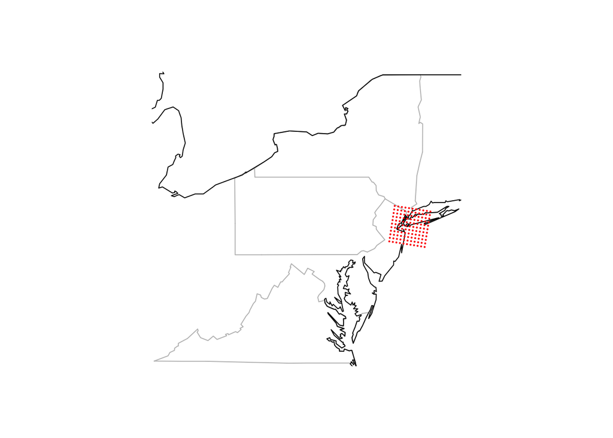

```r
map('state', regions = c('pennsylvania', 'new york', 'virginia'), col = 'grey')
map('usa', add = T)
points(forecast.xs - 360, forecast.ys, pch = 16, cex = .3, col = 'red')
```

Finally, let’s look at the dimensions of forecasts and analysis.

```r
print(dim(forecasts))
```

```
## [1]  10 121 576  36
```

```r
print(dim(analysis))
```

```
## [1]   10  121 2805
```

Forecasts have 4 dimensions. They are parameters, stations/grid points, days, and Forecast Lead Times (FLTs). Analysis have 3 dimensions. They are parameters, stations/grid points, and time.

## Generate Temperature Forecasts

Now that we have a general idea of the data, we can generate temperature forecasts. The steps to generate AnEn forecasts are as follow:

- Initialize a configuration
- Set up options
- Generate AnEn

```r
AnEn <- generateAnalogs(config)
```

```
## [1] "Warning: Converting data/time to numeric for search_times."
## [1] "Warning: Converting search_flts to a numeric vector."
## [1] "Warning: Converting data/time to numeric for search_observations"
## Convert R objects to C++ objects ...
## Wraping C++ object mapping ...
## Wraping C++ object analogs ...
## Done!
```

Then we need to bias correct AnEn because we are using AnEn on a gridded product.

```r
AnEn <- biasCorrection(AnEn, config, forecast.ID = 1, group.func = mean,
                       na.rm = T, show.progress = F)
```

`AnEn` is a list of results. Let’s check what we have in it.

```r
print(AnEn)
```

```
## Class: AnEn list
## Member 'analogs': [test station][test time][FLT][member][type]
## 121 1 36 19 3 (value, search station, search observation time)
## Member 'analogs.cor': [test station][test time][FLT][member][type]
## 121 1 36 19 3 (value, search station, search observation time)
## Member 'mapping': [FLT][forecast time] 36 370
```

## Visualization

Finally, we can plot together the analysis, the forecasts, the AnEn, and the bias corrected AnEn. Below the figures are the respective RMSE.

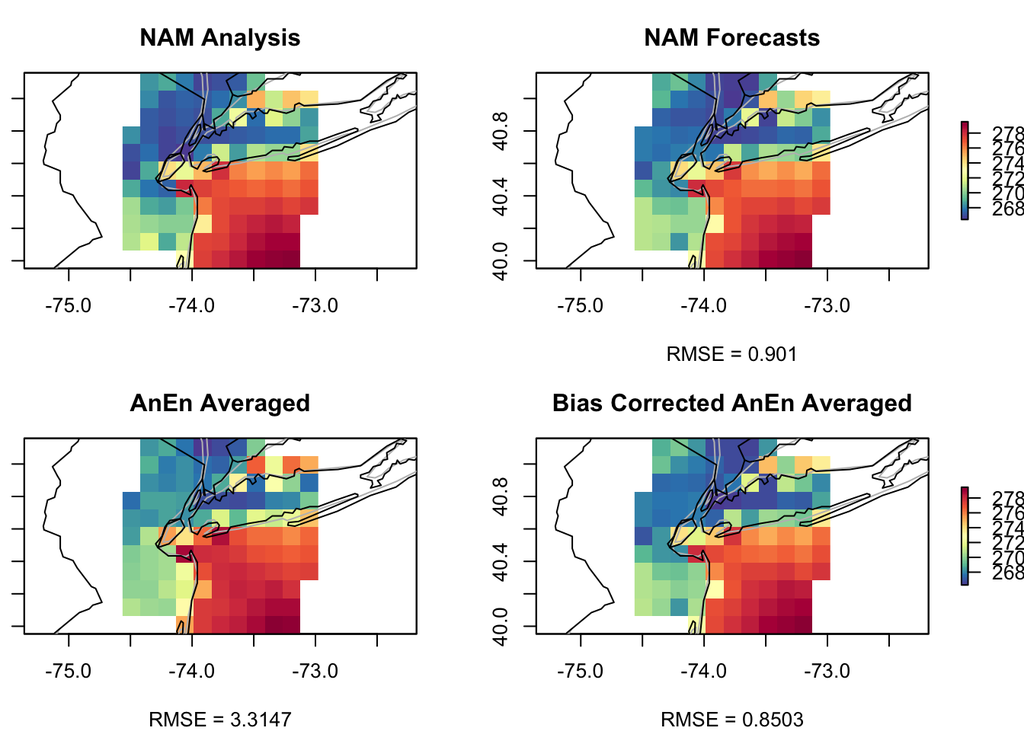